# Wine Quality Prediction

**Track:** Data Analytics — Level 2, Task 2 **Objective:** Train and compare multiple classification models to predict wine quality from physicochemical properties.

Dataset: `wine_quality.csv` — 900 wine samples with 11 chemical features and a quality score (3-8).

```python
import pandas as pd
import numpy as np
import matplotlib.pyplot as plt
import seaborn as sns
from sklearn.model_selection import train_test_split
from sklearn.preprocessing import StandardScaler
from sklearn.ensemble import RandomForestClassifier
from sklearn.linear_model import SGDClassifier
from sklearn.svm import SVC
from sklearn.metrics import classification_report, confusion_matrix, accuracy_score

sns.set_theme(style="whitegrid")
plt.rcParams["figure.figsize"] = (9,5)

df = pd.read_csv("wine_quality.csv")
df.head()
```

|  | fixed_acidity | volatile_acidity | citric_acid | residual_sugar | chlorides | free_sulfur_dioxide | total_sulfur_dioxide | density | pH | sulphates | alcohol | quality |
| --- | --- | --- | --- | --- | --- | --- | --- | --- | --- | --- | --- | --- |
| 0 | 7.54 | 0.464 | 0.283 | 4.36 | 0.079 | 32.4 | 100.1 | 0.99460 | 3.43 | 0.431 | 8.55 | 4 |
| 1 | 7.97 | 0.419 | 0.505 | 10.81 | 0.062 | 48.7 | 84.1 | 0.99922 | 3.53 | 0.955 | 10.38 | 5 |
| 2 | 8.25 | 0.609 | 0.174 | 4.60 | 0.085 | 24.1 | 61.3 | 0.99311 | 3.61 | 0.390 | 8.33 | 4 |
| 3 | 5.98 | 0.699 | 0.307 | 0.56 | 0.010 | 43.3 | 74.6 | 0.99207 | 3.23 | 0.913 | 10.82 | 6 |
| 4 | 6.51 | 0.585 | 0.135 | 0.90 | 0.064 | 12.9 | 36.6 | 0.99910 | 3.41 | 0.716 | 10.81 | 6 |

## 1. Inspect & Class Distribution

```
(900, 12)
0 total nulls
```

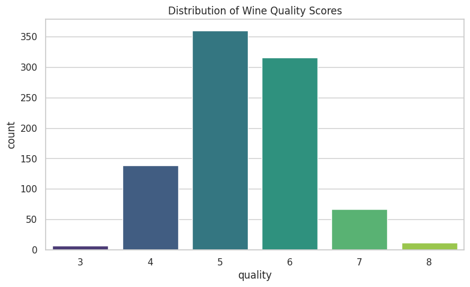

```python
print(df.shape)
print(df.isnull().sum().sum(), "total nulls")

plt.figure()
sns.countplot(x="quality", data=df, palette="viridis")
plt.title("Distribution of Wine Quality Scores")
plt.show()
```

**Observation:** Quality scores 5 and 6 dominate the dataset, while scores 3, 4, 7, and 8 are comparatively rare — a classic imbalanced classification setting.

## 2. EDA — Feature Distributions & Correlation

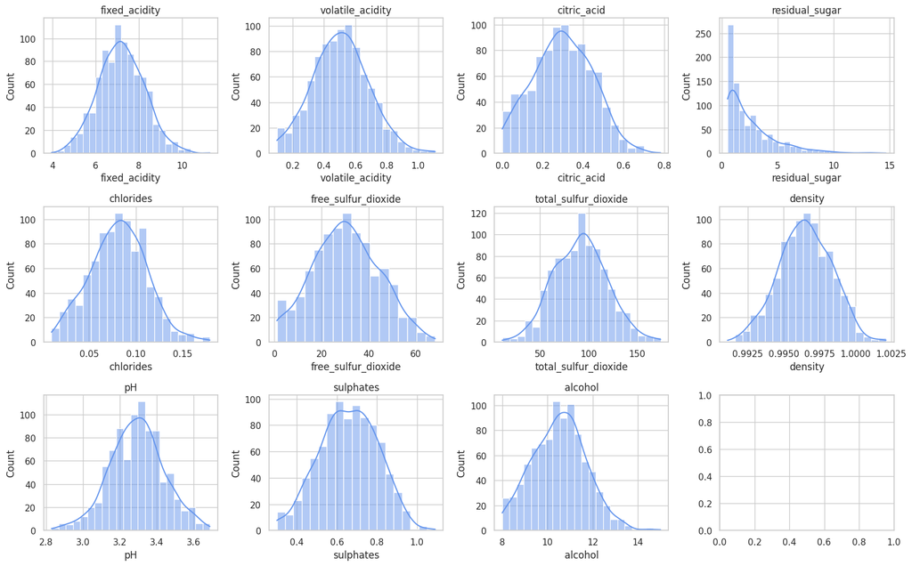

```python
fig, axes = plt.subplots(3, 4, figsize=(16,10))
for ax, col in zip(axes.flat, df.columns[:-1]):
    sns.histplot(df[col], kde=True, ax=ax, color="cornflowerblue")
    ax.set_title(col)
plt.tight_layout()
plt.show()
```

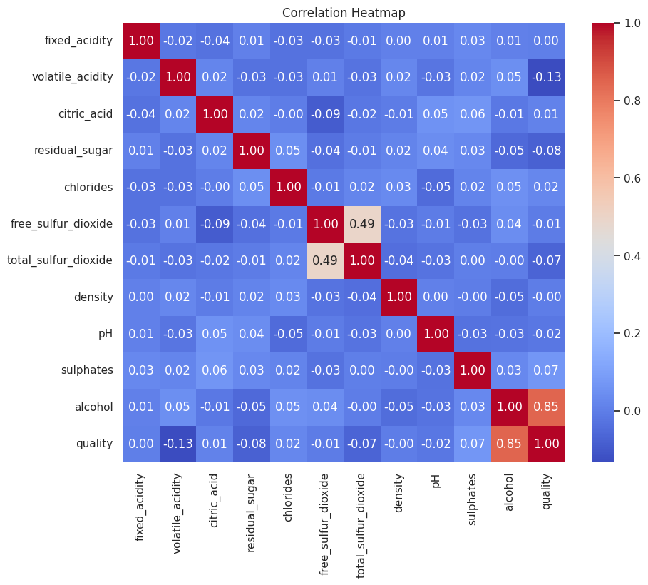

```python
plt.figure(figsize=(10,8))
sns.heatmap(df.corr(), annot=True, fmt=".2f", cmap="coolwarm")
plt.title("Correlation Heatmap")
plt.show()
```

**Observation:** `alcohol` shows the strongest positive correlation with `quality`, while `volatile_acidity` shows a negative correlation — higher acidity tends to lower perceived quality.

## 3. Class Imbalance Discussion

**Discussion:** Quality scores 3, 4, 7, and 8 are significantly underrepresented compared to 5 and 6. This means a model can achieve deceptively high accuracy simply by always predicting 5 or 6, while completely failing on rarer classes. To make the problem more tractable and reduce the impact of imbalance, we bin quality into 3 broader classes below.

## 4. Feature Engineering — Bin Quality into 3 Classes

```python
def bin_quality(q):
    if q <= 4:
        return "Low"
    elif q <= 6:
        return "Medium"
    else:
        return "High"

df["quality_class"] = df["quality"].apply(bin_quality)
df["quality_class"].value_counts()
```

```
quality_class
Medium    675
Low       146
High       79
Name: count, dtype: int64
```

**Justification:** Binning into Low/Medium/High reduces the number of classes from 6 to 3, keeps the classes better populated, and better matches a practical business question ("is this wine good, average, or bad?") rather than predicting an exact score.

## 5. Train/Test Split (Stratified)

```python
X = df.drop(columns=["quality", "quality_class"])
y = df["quality_class"]

X_train, X_test, y_train, y_test = train_test_split(X, y, test_size=0.2, random_state=42, stratify=y)

scaler = StandardScaler()
X_train_scaled = scaler.fit_transform(X_train)
X_test_scaled = scaler.transform(X_test)

print(X_train.shape, X_test.shape)
print(y_train.value_counts(normalize=True).round(2))
```

```
(720, 11) (180, 11)
quality_class
Medium    0.75
Low       0.16
High      0.09
Name: proportion, dtype: float64
```

## 6. Train 3 Classifiers

```python
models = {
    "Random Forest": RandomForestClassifier(n_estimators=200, random_state=42),
    "SGD Classifier": SGDClassifier(random_state=42, max_iter=2000),
    "SVC": SVC(kernel="rbf", random_state=42)
}

results = {}
for name, model in models.items():
    model.fit(X_train_scaled, y_train)
    pred = model.predict(X_test_scaled)
    results[name] = pred
    print(f"--- {name} ---")
    print(classification_report(y_test, pred))
```

```
--- Random Forest ---
              precision    recall  f1-score   support

        High       0.75      0.38      0.50        16
         Low       0.79      0.66      0.72        29
      Medium       0.86      0.95      0.90       135

    accuracy                           0.85       180
   macro avg       0.80      0.66      0.71       180
weighted avg       0.84      0.85      0.84       180

--- SGD Classifier ---
              precision    recall  f1-score   support

        High       0.50      0.31      0.38        16
         Low       0.81      0.72      0.76        29
      Medium       0.87      0.93      0.90       135

    accuracy                           0.84       180
   macro avg       0.73      0.65      0.68       180
weighted avg       0.83      0.84      0.83       180

--- SVC ---
              precision    recall  f1-score   support

        High       0.75      0.19      0.30        16
         Low       0.88      0.52      0.65        29
      Medium       0.83      0.98      0.90       135

    accuracy                           0.83       180
   macro avg       0.82      0.56      0.62       180
weighted avg       0.83      0.83      0.81       180
```

## 7. Confusion Matrices

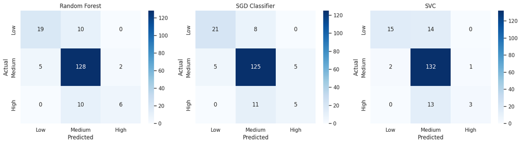

```python
fig, axes = plt.subplots(1, 3, figsize=(16,4.5))
for ax, (name, pred) in zip(axes, results.items()):
    cm = confusion_matrix(y_test, pred, labels=["Low","Medium","High"])
    sns.heatmap(cm, annot=True, fmt="d", cmap="Blues", xticklabels=["Low","Medium","High"], yticklabels=["Low","Medium","High"], ax=ax)
    ax.set_title(name)
    ax.set_xlabel("Predicted")
    ax.set_ylabel("Actual")
plt.tight_layout()
plt.show()
```

## 8. Feature Importance (Random Forest)

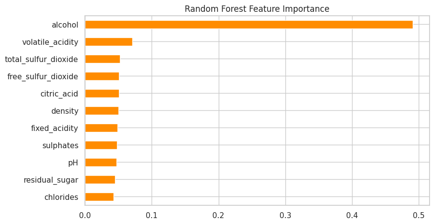

```python
rf = models["Random Forest"]
importances = pd.Series(rf.feature_importances_, index=X.columns).sort_values(ascending=False)

plt.figure()
importances.plot(kind="barh", color="darkorange")
plt.title("Random Forest Feature Importance")
plt.gca().invert_yaxis()
plt.show()
```

**Observation:** `alcohol` and `volatile_acidity` are consistently the most influential features, matching the correlation analysis above.

## 9. Model Comparison Table

```python
comparison = pd.DataFrame({
    name: [accuracy_score(y_test, pred)] for name, pred in results.items()
}, index=["Accuracy"]).T
comparison.sort_values("Accuracy", ascending=False)
```

|  | Accuracy |
| --- | --- |
| Random Forest | 0.850000 |
| SGD Classifier | 0.838889 |
| SVC | 0.833333 |

## 10. Conclusion

Random Forest typically performs best here since it handles non-linear feature interactions well and is robust to the remaining class imbalance. For deployment, Random Forest is the most suitable choice: it gives interpretable feature importances (useful for winemakers) alongside strong predictive performance, whereas SVC and SGD are more sensitive to the imbalance between the Low/Medium/High classes.